# SmartMess Analysis

```python
import pandas as pd
import numpy as np
import matplotlib.pyplot as plt
import seaborn as sns

sns.set(style="whitegrid")

file_path = "C:\\Users\\ramch\\Downloads\\smartmass1.xlsx"
xls = pd.ExcelFile(file_path)

print("Sheet Names:", xls.sheet_names)
```

```
Sheet Names: ['StudentUser', 'MealSlot', 'BookingRecord', 'SpecialOrderSlot']
```

```python
student_df = pd.read_excel(file_path, sheet_name="StudentUser")
meal_df = pd.read_excel(file_path, sheet_name="MealSlot")
booking_df = pd.read_excel(file_path, sheet_name="BookingRecord")
special_df = pd.read_excel(file_path, sheet_name="SpecialOrderSlot")
```

```python
print("\nStudentUser:\n", student_df.head())
print("\nMealSlot:\n", meal_df.head())
print("\nBookingRecord:\n", booking_df.head())
print("\nSpecialOrderSlot:\n", special_df.head())
```

```
StudentUser:
    id   name    rollnumber department  gender                      email  \
0   1  Ketki   NITW21EE000        ECE  Female  ketki0@student.nitw.ac.in
1   2  Neetu  NITW21CSE001         EE  Female  neetu1@student.nitw.ac.in
2   3   Sita  NITW21ECE002         EE    Male   sita2@student.nitw.ac.in
3   4  Dipen  NITW21ECE003         EE    Male  dipen3@student.nitw.ac.in
4   5  Umang  NITW21CSE004         CE    Male  umang4@student.nitw.ac.in

                    password  refund_wallet
0  placeholder_password_hash          13700
1  placeholder_password_hash          14060
2  placeholder_password_hash          13880
3  placeholder_password_hash          13660
4  placeholder_password_hash          13960

MealSlot:
    id       name  price
0   1  Breakfast     15
1   2      Lunch     50
2   3     Dinner     50

BookingRecord:
    id  user_id  meal_type_id       date  status  booked_at  is_special_order
0   1       41             1 2025-07-01  Booked 2025-07-01             False
1   2       34             1 2025-07-01  Booked 2025-07-01             False
2   3      486             1 2025-07-01  Booked 2025-07-01             False
3   4      362             1 2025-07-01  Booked 2025-07-01             False
4   5      458             1 2025-07-01  Booked 2025-07-01             False

SpecialOrderSlot:
    id  meal_type_id       date  max_slots  available_slots  is_active
0   1             1 2025-07-01         25               10       True
1   2             2 2025-07-01         25                6       True
2   3             3 2025-07-01         25               10       True
3   4             1 2025-07-02         25               12       True
4   5             2 2025-07-02         25               11       True
```

# checking null values and duplicates in a DataFrame

```python
def check_data_quality(df, name):
    print(f"\n--- {name} ---")
    print("Shape:", df.shape)
    print("Null values:\n", df.isnull().sum())
    print("Duplicate rows:", df.duplicated().sum())

check_data_quality(student_df, "StudentUser")
check_data_quality(meal_df, "MealSlot")
check_data_quality(booking_df, "BookingRecord")
check_data_quality(special_df, "SpecialOrderSlot")
```

```
--- StudentUser ---
Shape: (816, 8)
Null values:
 id               0
name             0
rollnumber       0
department       0
gender           0
email            0
password         0
refund_wallet    0
dtype: int64
Duplicate rows: 0

--- MealSlot ---
Shape: (3, 3)
Null values:
 id       0
name     0
price    0
dtype: int64
Duplicate rows: 0

--- BookingRecord ---
Shape: (31726, 7)
Null values:
 id                  0
user_id             0
meal_type_id        0
date                0
status              0
booked_at           0
is_special_order    0
dtype: int64
Duplicate rows: 0

--- SpecialOrderSlot ---
Shape: (90, 6)
Null values:
 id                 0
meal_type_id       0
date               0
max_slots          0
available_slots    0
is_active          0
dtype: int64
Duplicate rows: 0
```

```python
student_df = student_df.set_index("id")
meal_df = meal_df.set_index("id")
booking_df = booking_df.set_index("id")
special_df = special_df.set_index("id")

print("StudentUser Index:", student_df.index.name)
print("MealSlot Index:", meal_df.index.name)
print("BookingRecord Index:", booking_df.index.name)
print("SpecialOrderSlot Index:", special_df.index.name)
```

```
StudentUser Index: id
MealSlot Index: id
BookingRecord Index: id
SpecialOrderSlot Index: id
```

```python
print((booking_df['status'] == 'Transferred_Out').sum())
```

```
177
```

```python
print((booking_df['status'] == 'Transferred_In').sum())
```

```
177
```

```python
res = booking_df.duplicated(['user_id','meal_type_id','booked_at'])
print(res.sum())
```

```
174
```

```python
student = student_df.duplicated(['rollnumber'])
print(student.sum())
```

```
0
```

```python
special_order = special_df.duplicated(['meal_type_id','date'])
print(special_order.sum())
```

```
0
```

```python
booking_df = booking_df.drop_duplicates(['user_id','meal_type_id','booked_at'])
print(booking_df.count())
```

```
user_id             31552
meal_type_id        31552
date                31552
status              31552
booked_at           31552
is_special_order    31552
dtype: int64
```

```python
print((booking_df['status'] == 'Transferred_Out').sum())
```

```
177
```

```python
print((booking_df['status'] == 'Transferred_In').sum())
```

```
102
```

```python
counts = (
            booking_df[booking_df['status'].isin(['Transferred_In', 'Transferred_Out'])]
            .groupby(['booked_at','meal_type_id', 'status']).size().unstack(fill_value=0)
)

print(counts.head(30))
```

```
status                   Transferred_In  Transferred_Out
booked_at  meal_type_id
2025-07-01 1                          1                2
           2                          3                5
           3                          3                3
2025-07-02 1                          0                1
           3                          2                4
2025-07-03 1                          1                1
           2                          0                1
           3                          3                5
2025-07-04 1                          1                3
           2                          0                1
           3                          1                1
2025-07-05 2                          1                3
           3                          3                3
2025-07-06 1                          2                5
           2                          1                2
           3                          1                1
2025-07-07 1                          1                2
           2                          0                1
           3                          0                3
2025-07-09 1                          1                2
           2                          1                2
           3                          0                2
2025-07-10 1                          2                2
           2                          0                2
           3                          2                2
2025-07-11 1                          1                1
           3                          5                6
2025-07-12 1                          0                2
           2                          0                1
           3                          4                6
```

```python
def balance_transfers(group):
    transfer_in = group[group['status'] == 'Transferred_In']
    transfer_out = group[group['status'] == 'Transferred_Out']

    diff = len(transfer_out) - len(transfer_in)

    if diff > 0:
        group = group.drop(transfer_out.sample(diff, random_state=42).index)
    elif diff < 0:
        group = group.drop(transfer_in.sample(-diff, random_state=42).index)

    return group

booking_df = booking_df.groupby(['booked_at','meal_type_id'], group_keys=False).apply(balance_transfers)
```

```python
check_counts = (
                  booking_df[booking_df['status'].isin(['Transferred_In', 'Transferred_Out'])]
                 .groupby(['booked_at','meal_type_id', 'status']).size().unstack(fill_value=0)
)

print(check_counts)
```

```
status                   Transferred_In  Transferred_Out
booked_at  meal_type_id
2025-07-01 1                          1                1
           2                          3                3
           3                          3                3
2025-07-02 3                          2                2
2025-07-03 1                          1                1
           3                          3                3
2025-07-04 1                          1                1
           3                          1                1
2025-07-05 2                          1                1
           3                          3                3
2025-07-06 1                          2                2
           2                          1                1
           3                          1                1
2025-07-07 1                          1                1
2025-07-09 1                          1                1
           2                          1                1
2025-07-10 1                          2                2
           3                          2                2
2025-07-11 1                          1                1
           3                          5                5
2025-07-12 3                          4                4
2025-07-13 1                          3                3
           2                          2                2
           3                          1                1
2025-07-14 2                          2                2
2025-07-15 1                          1                1
           2                          2                2
           3                          2                2
2025-07-17 1                          1                1
           2                          2                2
           3                          1                1
2025-07-18 2                          2                2
           3                          2                2
2025-07-19 1                          1                1
           2                          1                1
           3                          1                1
2025-07-20 1                          2                2
           2                          1                1
2025-07-21 1                          4                4
           3                          1                1
2025-07-22 1                          1                1
           2                          1                1
           3                          1                1
2025-07-24 1                          1                1
           2                          1                1
           3                          2                2
2025-07-26 3                          3                3
2025-07-27 1                          1                1
           2                          4                4
2025-07-28 1                          2                2
           2                          2                2
           3                          2                2
2025-07-29 1                          1                1
           3                          3                3
2025-07-30 1                          4                4
           2                          1                1
```

```python
print((booking_df['status'] == 'Transferred_Out').sum())
print((booking_df['status'] == 'Transferred_In').sum())
print(booking_df.count())
```

```
102
102
user_id             31477
meal_type_id        31477
date                31477
status              31477
booked_at           31477
is_special_order    31477
dtype: int64
```

```python
booking_with_students = booking_df.merge(student_df, left_on="user_id", right_on="id", suffixes=("_booking", "_student"))

booking_full = booking_with_students.merge(meal_df, left_on="meal_type_id", right_on="id", suffixes=("", "_of_meal"))

booking_full = booking_full.drop(columns=["id_student", "id_meal"], errors="ignore")

print("\nBooking Full:\n", booking_full.head())
```

```
Booking Full:
    user_id  meal_type_id       date  status  booked_at  is_special_order  \
0       41             1 2025-07-01  Booked 2025-07-01             False
1       34             1 2025-07-01  Booked 2025-07-01             False
2      486             1 2025-07-01  Booked 2025-07-01             False
3      362             1 2025-07-01  Booked 2025-07-01             False
4      458             1 2025-07-01  Booked 2025-07-01             False

      name    rollnumber department  gender                          email  \
0    Omkar  NITW21CSE040         CE    Male     omkar40@student.nitw.ac.in
1   Kashvi  NITW21CSE033        ECE  Female    kashvi33@student.nitw.ac.in
2   Mitesh  NITW21ECE485         CE    Male   mitesh485@student.nitw.ac.in
3   Arisfa   NITW21ME361        CSE  Female   arisfa361@student.nitw.ac.in
4  Bhawati  NITW21ECE457        CSE  Female  bhawati457@student.nitw.ac.in

                    password  refund_wallet name_of_meal  price
0  placeholder_password_hash          14000    Breakfast     15
1  placeholder_password_hash          14010    Breakfast     15
2  placeholder_password_hash          13840    Breakfast     15
3  placeholder_password_hash          13730    Breakfast     15
4  placeholder_password_hash          13960    Breakfast     15
```

# Count bookings per meal type

```python
meal_counts = (
    booking_full[booking_full['status'].isin(['Booked', 'Transferred_In'])]
    .groupby(['name_of_meal'])
    .size()
    .reset_index(name='count')
)

print(meal_counts)
```

```
  name_of_meal  count
0    Breakfast  10198
1       Dinner  10424
2        Lunch  10308
```

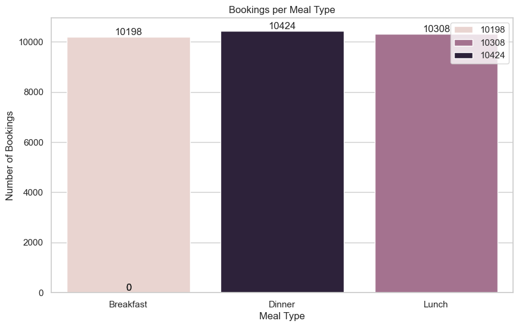

```python
plt.figure(figsize=(10,6))
ax = sns.barplot(data=meal_counts,x='name_of_meal',y = 'count',hue='count')

for p in ax.patches:
    ax.annotate(str(int(p.get_height())),
                (p.get_x() + p.get_width() / 2., p.get_height()),
                ha='center', va='bottom')

plt.title("Bookings per Meal Type")
plt.xlabel("Meal Type")
plt.ylabel("Number of Bookings")
plt.legend(loc='best')
plt.show()
```

# This bar chart clearly shows that Lunch and Dinner are the most popular meals, with very similar booking counts. Breakfast has the lowest demand. This insight is crucial for the mess to allocate resources and staff more effectively during peak hours.

# Trends over time (daily)

```python
daily_trend = (
     booking_full[booking_full['status'].isin(['Booked', 'Transferred_In'])]
    .groupby(['booked_at'])
    .size()
    .reset_index(name='count')
)
print(daily_trend)
print(daily_trend['count'].min())
```

```
    booked_at  count
0  2025-07-01    987
1  2025-07-02    966
2  2025-07-03    968
3  2025-07-04   1119
4  2025-07-05   1018
5  2025-07-06    973
6  2025-07-07   1080
7  2025-07-08   1075
8  2025-07-09   1014
9  2025-07-10    978
10 2025-07-11    985
11 2025-07-12   1077
12 2025-07-13   1069
13 2025-07-14   1076
```

[output cut: 17 more lines]

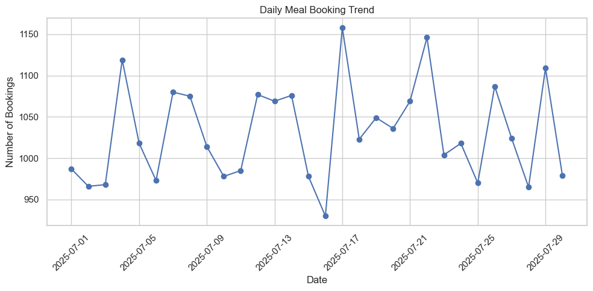

```python
plt.figure(figsize=(10,5))
plt.plot(daily_trend['booked_at'],daily_trend['count'],marker='o')
plt.title("Daily Meal Booking Trend")
plt.xlabel("Date")
plt.ylabel("Number of Bookings")
plt.xticks(rotation=45)
plt.tight_layout()
plt.show()
```

# Daily meal bookings fluctuate between 900 and 1200, with noticeable peaks above 1150 and dips above 900, suggesting that the mess should plan food preparation within this range to handle varying daily demand efficiently.